# Data Science Project on Classification of Iris Flowers

# Notebook Setup

```python
!where python
```

```
C:\Users\gtanu\AppData\Local\Programs\Python\Python310\python.exe
C:\Users\gtanu\anaconda3\python.exe
```

```python
%load_ext autoreload
%autoreload 2
%matplotlib inline
```

```
The autoreload extension is already loaded. To reload it, use:
  %reload_ext autoreload
```

```python
#Standard imports
import os

#Third-party imports
import pandas as pd
import numpy as np
import matplotlib.pyplot as plt
import seaborn as sns
from sklearn import datasets
#Local imports
```

```python
sns.set()
```

# Load Data

Let's load the iris flower dataset using scikit-learn built-in datset

```python
data = datasets.load_iris()
```

```python
data.keys()
```

```
dict_keys(['data', 'target', 'frame', 'target_names', 'DESCR', 'feature_names', 'filename', 'data_module'])
```

```python
data['data'][:5]
```

```
array([[5.1, 3.5, 1.4, 0.2],
       [4.9, 3. , 1.4, 0.2],
       [4.7, 3.2, 1.3, 0.2],
       [4.6, 3.1, 1.5, 0.2],
       [5. , 3.6, 1.4, 0.2]])
```

```python
data["feature_names"]
```

```
['sepal length (cm)',
 'sepal width (cm)',
 'petal length (cm)',
 'petal width (cm)']
```

```python
data["target"]
```

```
array([0, 0, 0, 0, 0, 0, 0, 0, 0, 0, 0, 0, 0, 0, 0, 0, 0, 0, 0, 0, 0, 0,
       0, 0, 0, 0, 0, 0, 0, 0, 0, 0, 0, 0, 0, 0, 0, 0, 0, 0, 0, 0, 0, 0,
       0, 0, 0, 0, 0, 0, 1, 1, 1, 1, 1, 1, 1, 1, 1, 1, 1, 1, 1, 1, 1, 1,
       1, 1, 1, 1, 1, 1, 1, 1, 1, 1, 1, 1, 1, 1, 1, 1, 1, 1, 1, 1, 1, 1,
       1, 1, 1, 1, 1, 1, 1, 1, 1, 1, 1, 1, 2, 2, 2, 2, 2, 2, 2, 2, 2, 2,
       2, 2, 2, 2, 2, 2, 2, 2, 2, 2, 2, 2, 2, 2, 2, 2, 2, 2, 2, 2, 2, 2,
       2, 2, 2, 2, 2, 2, 2, 2, 2, 2, 2, 2, 2, 2, 2, 2, 2, 2])
```

```python
data["target_names"]
```

```
array(['setosa', 'versicolor', 'virginica'], dtype='<U10')
```

## What problem are we trying to solve?

We are trying to use attributes of flowers to predict the species of flower. Specifically, we are using sepal length, sepal width, petal length and petal width to predict if an Iris flower is of type *Setosa*, *Versicolour* or *Virginica*.

This is a multiclass classification problem.

# Create a pandas DataFrame from the data

```python
df = pd.DataFrame(data["data"], columns = data["feature_names"])
```

```python
df["target"] = data["target"]
```

```python
df.head()
```

|  | sepal length (cm) | sepal width (cm) | petal length (cm) | petal width (cm) | target |
| --- | --- | --- | --- | --- | --- |
| 0 | 5.1 | 3.5 | 1.4 | 0.2 | 0 |
| 1 | 4.9 | 3.0 | 1.4 | 0.2 | 0 |
| 2 | 4.7 | 3.2 | 1.3 | 0.2 | 0 |
| 3 | 4.6 | 3.1 | 1.5 | 0.2 | 0 |
| 4 | 5.0 | 3.6 | 1.4 | 0.2 | 0 |

## Basic Descriptive Statistics

```python
df.describe()
```

|  | sepal length (cm) | sepal width (cm) | petal length (cm) | petal width (cm) | target |
| --- | --- | --- | --- | --- | --- |
| count | 150.000000 | 150.000000 | 150.000000 | 150.000000 | 150.000000 |
| mean | 5.843333 | 3.057333 | 3.758000 | 1.199333 | 1.000000 |
| std | 0.828066 | 0.435866 | 1.765298 | 0.762238 | 0.819232 |
| min | 4.300000 | 2.000000 | 1.000000 | 0.100000 | 0.000000 |
| 25% | 5.100000 | 2.800000 | 1.600000 | 0.300000 | 0.000000 |
| 50% | 5.800000 | 3.000000 | 4.350000 | 1.300000 | 1.000000 |
| 75% | 6.400000 | 3.300000 | 5.100000 | 1.800000 | 2.000000 |
| max | 7.900000 | 4.400000 | 6.900000 | 2.500000 | 2.000000 |

# Distribution of Features and Targets

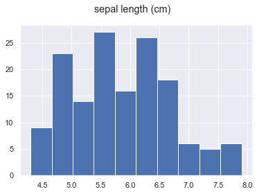

```python
col = "sepal length (cm)"
df[col].hist()
plt.suptitle(col)
plt.show()
```

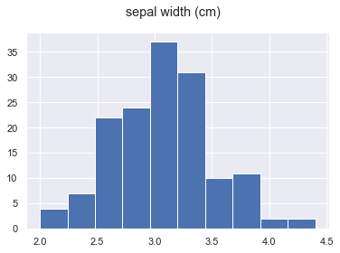

```python
col = "sepal width (cm)"
df[col].hist()
plt.suptitle(col)
plt.show()
```

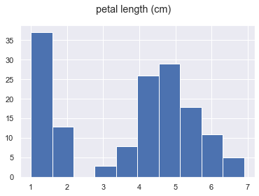

```python
col = "petal length (cm)"
df[col].hist()
plt.suptitle(col)
plt.show()
```

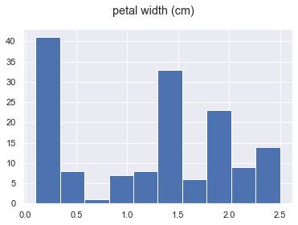

```python
col = "petal width (cm)"
df[col].hist()
plt.suptitle(col)
plt.show()
```

# Relationship of the data features with the target

```python
data["target_names"]
```

```
array(['setosa', 'versicolor', 'virginica'], dtype='<U10')
```

```python
#Create a new column with the species name
df["target_name"] = df["target"].map({0: "setosa", 1: "versicolor", 2:"virginica"})
```

```python
df
```

|  | sepal length (cm) | sepal width (cm) | petal length (cm) | petal width (cm) | target | target_name |
| --- | --- | --- | --- | --- | --- | --- |
| 0 | 5.1 | 3.5 | 1.4 | 0.2 | 0 | setosa |
| 1 | 4.9 | 3.0 | 1.4 | 0.2 | 0 | setosa |
| 2 | 4.7 | 3.2 | 1.3 | 0.2 | 0 | setosa |
| 3 | 4.6 | 3.1 | 1.5 | 0.2 | 0 | setosa |
| 4 | 5.0 | 3.6 | 1.4 | 0.2 | 0 | setosa |
| ... | ... | ... | ... | ... | ... | ... |
| 145 | 6.7 | 3.0 | 5.2 | 2.3 | 2 | virginica |
| 146 | 6.3 | 2.5 | 5.0 | 1.9 | 2 | virginica |
| 147 | 6.5 | 3.0 | 5.2 | 2.0 | 2 | virginica |
| 148 | 6.2 | 3.4 | 5.4 | 2.3 | 2 | virginica |
| 149 | 5.9 | 3.0 | 5.1 | 1.8 | 2 | virginica |

150 rows × 6 columns

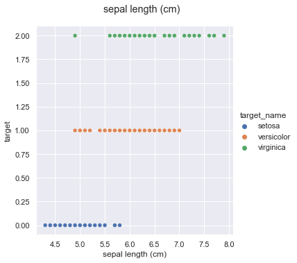

```python
col = "sepal length (cm)"
sns.relplot(x = col, y = "target", hue = "target_name", data = df)
plt.suptitle(col, y = 1.05)
plt.show()
```

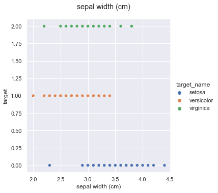

```python
col = "sepal width (cm)"
sns.relplot(x = col, y = "target", hue = "target_name", data = df)
plt.suptitle(col, y = 1.05)
plt.show()
```

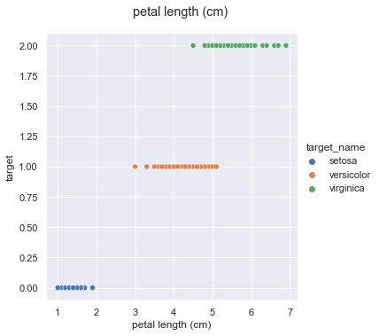

```python
col = "petal length (cm)"
sns.relplot(x = col, y = "target", hue = "target_name", data = df)
plt.suptitle(col, y = 1.05)
plt.show()
```

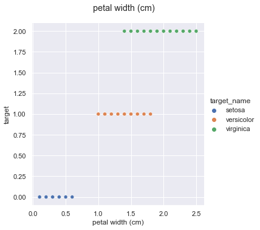

```python
col = "petal width (cm)"
sns.relplot(x = col, y = "target", hue = "target_name", data = df)
plt.suptitle(col, y = 1.05)
plt.show()
```

# Exploratory Data Analysis(EDA) - Pair Plots

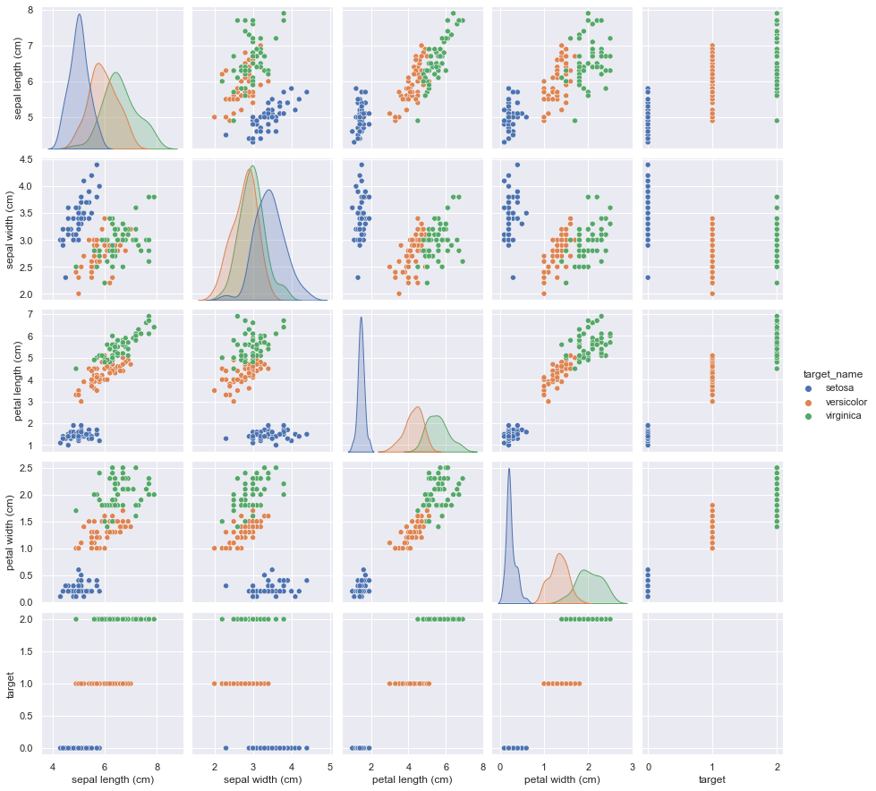

```python
sns.pairplot(df, hue = "target_name")
plt.show()
```

# Train Test Split

You always want to evaluate your final model on a test set that hasn't been used at all in the training process. So we will split off a test set here.

*(Note: This might be a little less true if we use cross-validation, but still it's considered best practice.)*

```python
from sklearn.model_selection import train_test_split
```

```python
df_train, df_test = train_test_split(df, test_size = 0.25)
```

```python
df_train.shape
```

```
(112, 6)
```

```python
df_test.shape
```

```
(38, 6)
```

```python
df_train.head()
```

|  | sepal length (cm) | sepal width (cm) | petal length (cm) | petal width (cm) | target | target_name |
| --- | --- | --- | --- | --- | --- | --- |
| 10 | 5.4 | 3.7 | 1.5 | 0.2 | 0 | setosa |
| 42 | 4.4 | 3.2 | 1.3 | 0.2 | 0 | setosa |
| 57 | 4.9 | 2.4 | 3.3 | 1.0 | 1 | versicolor |
| 128 | 6.4 | 2.8 | 5.6 | 2.1 | 2 | virginica |
| 8 | 4.4 | 2.9 | 1.4 | 0.2 | 0 | setosa |

# Preparing our data for modelling

This invloves splitting the data back out into plain Numpy arrays

```python
x_train = df_train.drop(columns = ["target" , "target_name"]).values
y_train = df_train["target"].values
```

```python
y_train
```

```
array([0, 0, 1, 2, 0, 2, 0, 2, 1, 0, 1, 0, 1, 1, 1, 2, 1, 1, 0, 0, 1, 1,
       0, 2, 2, 2, 2, 2, 0, 1, 2, 0, 0, 0, 0, 2, 1, 1, 1, 1, 2, 1, 0, 2,
       2, 1, 1, 0, 1, 0, 1, 1, 2, 1, 2, 2, 1, 2, 0, 1, 1, 2, 2, 1, 2, 0,
       1, 2, 1, 0, 1, 1, 2, 0, 2, 0, 0, 1, 0, 0, 0, 2, 1, 1, 1, 0, 0, 1,
       1, 0, 2, 0, 0, 2, 2, 1, 2, 2, 2, 0, 1, 2, 2, 2, 2, 2, 2, 0, 0, 1,
       2, 1])
```

# Modeling - What is our baseline?

What is the simplest model we can think of?

In this case, if our baseline model is just randomly guessing the species of flower, or guessing a single species for every data point, we would expect to have a model accuracy of 0.33 or 33%, since we have 3 different classes that are evenly balanced.

So our model should atleast beat 33% accuracy.

# Modeling - Simple manual model

Let's manually look at our data and decide some cutoff points for classification.

```python
def single_feature_prediction(petal_length):
    """Predicts the Irirs Species given the petal length"""
    if petal_length < 2.5:
        return 0
    elif petal_length < 4.8:
        return 1
    else:
        return 2
```

```python
x_train[:, 2]
```

```
array([1.5, 1.3, 3.3, 5.6, 1.4, 5.3, 1.5, 5.1, 4.7, 1.6, 4.6, 1.3, 4.9,
       4.6, 4. , 5.6, 4.1, 4.4, 1.4, 1.4, 4.6, 4. , 1.5, 6. , 5.8, 5.3,
       5.4, 5.7, 1.5, 4.2, 5.1, 1.9, 1.5, 1.9, 1.5, 6.7, 4.2, 3.8, 4.3,
       5.1, 5.9, 4. , 1.2, 5.9, 4.9, 4.5, 4.7, 1.4, 3.5, 1.7, 3. , 4.8,
       4.8, 4.5, 5. , 4.9, 4.1, 6.3, 1.7, 4.5, 4.3, 5. , 5.5, 3.9, 5.6,
       1.3, 4.5, 5.2, 4. , 1.4, 4.4, 4.5, 5.2, 1.6, 4.8, 1.5, 1.4, 4.2,
       1.3, 1.7, 1.3, 5.7, 4.2, 4.9, 4.4, 1.6, 1.5, 4.4, 4.5, 1.5, 5.1,
       1.6, 1.4, 5.1, 4.9, 4.1, 5.1, 5.6, 5.6, 1.5, 3.6, 6.7, 5. , 5.6,
       5.7, 6.1, 6.1, 1.4, 1.6, 4.7, 6.9, 3.7])
```

```python
manual_y_predictions = np.array([single_feature_prediction(val) for val in x_train[:, 2]])
```

```python
y_train
```

```
array([0, 0, 1, 2, 0, 2, 0, 2, 1, 0, 1, 0, 1, 1, 1, 2, 1, 1, 0, 0, 1, 1,
       0, 2, 2, 2, 2, 2, 0, 1, 2, 0, 0, 0, 0, 2, 1, 1, 1, 1, 2, 1, 0, 2,
       2, 1, 1, 0, 1, 0, 1, 1, 2, 1, 2, 2, 1, 2, 0, 1, 1, 2, 2, 1, 2, 0,
       1, 2, 1, 0, 1, 1, 2, 0, 2, 0, 0, 1, 0, 0, 0, 2, 1, 1, 1, 0, 0, 1,
       1, 0, 2, 0, 0, 2, 2, 1, 2, 2, 2, 0, 1, 2, 2, 2, 2, 2, 2, 0, 0, 1,
       2, 1])
```

```python
manual_model_accuracy = np.mean(manual_y_predictions == y_train)
```

```python
print(f" Manual model Accuracy = {manual_model_accuracy * 100:.2f}%")
```

```
 Manual model Accuracy = 96.43%
```

# Modeling - Logistic Regression

```python
from sklearn.linear_model import LogisticRegression
```

### Using a validation set to evaluation our model

```python
model = LogisticRegression(max_iter = 200)
```

```python
# Xt stands for "x_train" and Xv stands for "x_validation"
Xt, Xv , Yt, Yv = train_test_split(x_train, y_train, test_size = 0.25)
```

```python
model.fit(Xt, Yt)
```

```
LogisticRegression(max_iter=200)
```

```python
y_pred = model.predict(Xv)
```

```python
np.mean(y_pred == Yv)
```

```
0.9642857142857143
```

```python
model.score(Xv, Yv) #You never want to evaluate your model on the same data that you used for training
```

```
0.9642857142857143
```

## Use cross validation to evaluate your model

```python
from sklearn.model_selection import cross_val_score, cross_val_predict
```

```python
model = LogisticRegression(max_iter = 200)
```

```python
accuracies = cross_val_score(model, x_train, y_train , cv = 5, scoring = "accuracy")
```

```python
np.mean(accuracies)
```

```
0.9644268774703558
```

# Where are we misclassifying points?

```python
y_pred = cross_val_predict(model, x_train, y_train, cv = 5)
```

```python
predicted_correctly_mask = y_pred == y_train
```

```python
predicted_correctly_mask
```

```
array([ True,  True,  True,  True,  True,  True,  True,  True,  True,
        True,  True,  True,  True,  True,  True,  True,  True,  True,
        True,  True,  True,  True,  True,  True,  True,  True,  True,
        True,  True,  True,  True,  True,  True,  True,  True,  True,
        True,  True,  True, False,  True,  True,  True,  True,  True,
        True,  True,  True,  True,  True,  True, False,  True,  True,
       False,  True,  True,  True,  True,  True,  True,  True,  True,
        True,  True,  True,  True,  True,  True,  True,  True,  True,
        True,  True, False,  True,  True,  True,  True,  True,  True,
        True,  True,  True,  True,  True,  True,  True,  True,  True,
        True,  True,  True,  True,  True,  True,  True,  True,  True,
        True,  True,  True,  True,  True,  True,  True,  True,  True,
        True,  True,  True,  True])
```

```python
not_predicted_correctly = ~predicted_correctly_mask
```

```python
x_train[not_predicted_correctly]
```

```
array([[6. , 2.7, 5.1, 1.6],
       [5.9, 3.2, 4.8, 1.8],
       [6. , 2.2, 5. , 1.5],
       [6.2, 2.8, 4.8, 1.8]])
```

```python
df_predictions = df_train.copy()
```

```python
df_predictions["correct_prediction"] = predicted_correctly_mask
```

```python
df_predictions.head()
```

|  | sepal length (cm) | sepal width (cm) | petal length (cm) | petal width (cm) | target | target_name | correct_prediction |
| --- | --- | --- | --- | --- | --- | --- | --- |
| 10 | 5.4 | 3.7 | 1.5 | 0.2 | 0 | setosa | True |
| 42 | 4.4 | 3.2 | 1.3 | 0.2 | 0 | setosa | True |
| 57 | 4.9 | 2.4 | 3.3 | 1.0 | 1 | versicolor | True |
| 128 | 6.4 | 2.8 | 5.6 | 2.1 | 2 | virginica | True |
| 8 | 4.4 | 2.9 | 1.4 | 0.2 | 0 | setosa | True |

```python
df_predictions["prediction"] = y_pred
```

```python
df_predictions["prediction_label"] = df_predictions["prediction"].map({0: "setosa", 1: "versicolor", 2:"virginica"})
```

```python
df_predictions.head()
```

|  | sepal length (cm) | sepal width (cm) | petal length (cm) | petal width (cm) | target | target_name | correct_prediction | prediction | prediction_label |
| --- | --- | --- | --- | --- | --- | --- | --- | --- | --- |
| 10 | 5.4 | 3.7 | 1.5 | 0.2 | 0 | setosa | True | 0 | setosa |
| 42 | 4.4 | 3.2 | 1.3 | 0.2 | 0 | setosa | True | 0 | setosa |
| 57 | 4.9 | 2.4 | 3.3 | 1.0 | 1 | versicolor | True | 1 | versicolor |
| 128 | 6.4 | 2.8 | 5.6 | 2.1 | 2 | virginica | True | 2 | virginica |
| 8 | 4.4 | 2.9 | 1.4 | 0.2 | 0 | setosa | True | 0 | setosa |

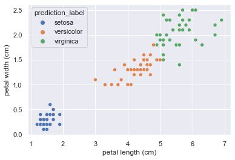

```python
sns.scatterplot(x = "petal length (cm)", y = "petal width (cm)", hue = "prediction_label", data = df_predictions)
plt.show()
```

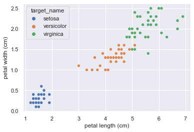

```python
sns.scatterplot(x = "petal length (cm)", y = "petal width (cm)", hue = "target_name", data = df_predictions)
plt.show()
```

```python
def plot_incorrect_predictions(df_predictions, x_axis_feature, y_axis_feature):
    fig, axs = plt.subplots(2, 2, figsize = (10, 10))
    axs = axs.flatten()
    sns.scatterplot(x = x_axis_feature , y = y_axis_feature, hue = "prediction_label", data = df_predictions, ax = axs[0])
    sns.scatterplot(x = x_axis_feature , y = y_axis_feature, hue = "target_name", data = df_predictions, ax = axs[1])
    sns.scatterplot(x = x_axis_feature , y = y_axis_feature, hue = "correct_prediction", data = df_predictions, ax = axs[2])
    axs[3].set_visible(False)

    plt.show()
```

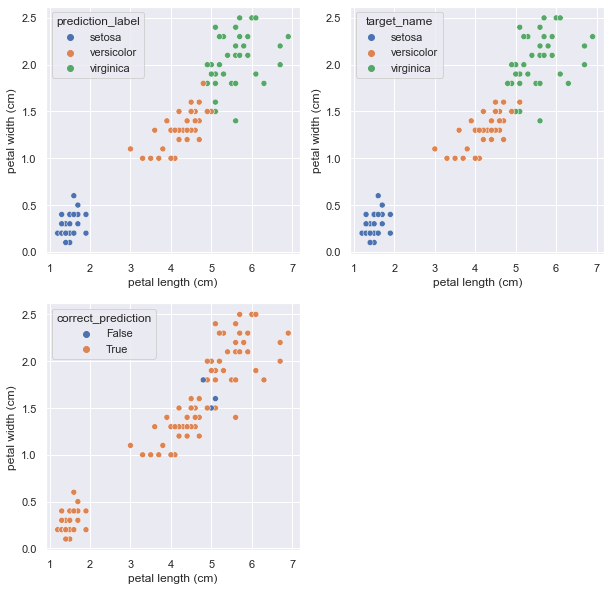

```python
plot_incorrect_predictions(df_predictions, "petal length (cm)" , "petal width (cm)")
```

# Model Tuning

What is model tuning?

Model Tuning is trying to determine the parameters of your model ("also known as hyperparameters") that maximize your model performance.

```python
for reg_param in (1, 1.3, 1.8, 2, 2.3, 2.9, 3):
    print(reg_param)
    model = LogisticRegression(max_iter = 200, C = reg_param)
    accuracies = cross_val_score(model, x_train, y_train, cv = 5, scoring = "accuracy")
    print(f"Accuracy:{np.mean(accuracies) * 100:.2f}%")
```

```
1
Accuracy:96.44%
1.3
Accuracy:98.22%
1.8
Accuracy:98.22%
2
Accuracy:98.22%
2.3
Accuracy:98.22%
2.9
Accuracy:98.22%
3
Accuracy:98.22%
```

# Final Model

```python
model = LogisticRegression(max_iter = 200, C = 2)
```

# How well our model does on the test set?

```python
x_test = df_test.drop(columns = ["target" , "target_name"]).values
y_test = df_test["target"].values
```

```python
x_test.shape
```

```
(38, 4)
```

```python
y_test
```

```
array([1, 1, 0, 1, 1, 1, 2, 2, 2, 2, 0, 0, 1, 0, 1, 0, 1, 0, 2, 1, 2, 2,
       2, 0, 1, 0, 0, 2, 0, 2, 2, 0, 0, 0, 0, 2, 0, 0])
```

# Train our final model using our full training dataset

```python
model.fit(x_train, y_train)
```

```
LogisticRegression(C=2, max_iter=200)
```

```python
y_test_pred = model.predict(x_test)
```

```python
test_set_correctly_classified = y_test_pred == y_test
test_set_accuracy = np.mean(test_set_correctly_classified)
```

```python
print(f"Test set Accuracy: {test_set_accuracy * 100:.2f}%")
```

```
Test set Accuracy: 94.74%
```

```python
test_set_correctly_classified
```

```
array([False,  True,  True,  True,  True,  True,  True,  True,  True,
       False,  True,  True,  True,  True,  True,  True,  True,  True,
        True,  True,  True,  True,  True,  True,  True,  True,  True,
        True,  True,  True,  True,  True,  True,  True,  True,  True,
        True,  True])
```

```python
df_predictions_test = df_test.copy()
df_predictions_test["correct_prediction"] = test_set_correctly_classified
df_predictions_test["prediction"] = y_test_pred
df_predictions_test["prediction_label"] = df_predictions_test["prediction"].map({0: "setosa", 1: "versicolor", 2:"virginica"})
```

```python
df_predictions_test.head()
```

|  | sepal length (cm) | sepal width (cm) | petal length (cm) | petal width (cm) | target | target_name | correct_prediction | prediction | prediction_label |
| --- | --- | --- | --- | --- | --- | --- | --- | --- | --- |
| 77 | 6.7 | 3.0 | 5.0 | 1.7 | 1 | versicolor | False | 2 | virginica |
| 60 | 5.0 | 2.0 | 3.5 | 1.0 | 1 | versicolor | True | 1 | versicolor |
| 22 | 4.6 | 3.6 | 1.0 | 0.2 | 0 | setosa | True | 0 | setosa |
| 86 | 6.7 | 3.1 | 4.7 | 1.5 | 1 | versicolor | True | 1 | versicolor |
| 93 | 5.0 | 2.3 | 3.3 | 1.0 | 1 | versicolor | True | 1 | versicolor |

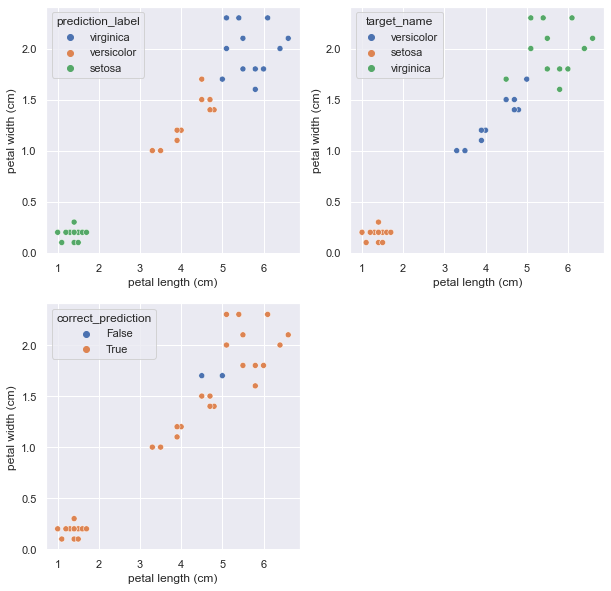

```python
plot_incorrect_predictions(df_predictions_test, x_axis_feature = "petal length (cm)", y_axis_feature = "petal width (cm)")
```

# In Conclusion

We achieved a 95% accuracy on the test dataset using a Logistic Regression model.